# Predict Conversation Success Satisfaction

**Predict Conversation Success Satisfaction**

y: whether a conversation resolves the user’s issue

X: early message count, tokens in first 5 minutes, model tier, user tier, type of question (if you have categories), response time

Goal: route required conversations to more capable models or human agent handoff

```python
import pandas as pd
import numpy as np
import matplotlib.pyplot as plt
import seaborn as sns

from sklearn.model_selection import train_test_split
from sklearn.preprocessing import StandardScaler, OneHotEncoder
from sklearn.compose import ColumnTransformer

from sklearn.neighbors import KNeighborsClassifier
from sklearn.linear_model import LogisticRegression
from sklearn.discriminant_analysis import LinearDiscriminantAnalysis as LDA
from sklearn.discriminant_analysis import QuadraticDiscriminantAnalysis as QDA

from sklearn.metrics import confusion_matrix, classification_report, accuracy_score, ConfusionMatrixDisplay
```

```python
df=pd.read_csv("Chatbot Pricing Data - KNN Data.csv")
df.head()
```

|  | convo_id | msg_count_5min | tokens_5min | avg_tokens_per_msg | model_tier | user_tier | total_cost_usd | msg_count_5min_norm | tokens_5min_norm | avg_tokens_per_msg_norm | model_tier_norm | user_tier_norm |
| --- | --- | --- | --- | --- | --- | --- | --- | --- | --- | --- | --- | --- |
| 0 | PK001 | 8 | 880 | 110.000000 | 1 | 2 | 0.18 | 0.333333 | 0.242565 | 0.068298 | 0.0 | 0.5 |
| 1 | HG002 | 19 | 1372 | 72.210526 | 2 | 3 | 0.55 | 0.944444 | 0.418846 | 0.042131 | 0.5 | 1.0 |
| 2 | YB003 | 7 | 2891 | 413.000000 | 3 | 3 | 1.73 | 0.277778 | 0.963096 | 0.278113 | 1.0 | 1.0 |
| 3 | ZW004 | 19 | 2350 | 123.684211 | 2 | 1 | 0.94 | 0.944444 | 0.769258 | 0.077774 | 0.5 | 0.0 |
| 4 | HB005 | 9 | 643 | 71.444444 | 3 | 2 | 0.39 | 0.388889 | 0.157650 | 0.041600 | 1.0 | 0.5 |

```python
df.shape
df.describe
df.columns
```

```
Index(['convo_id', 'msg_count_5min', 'tokens_5min', 'avg_tokens_per_msg',
       'model_tier', 'user_tier', 'total_cost_usd', 'msg_count_5min_norm',
       'tokens_5min_norm', 'avg_tokens_per_msg_norm', 'model_tier_norm',
       'user_tier_norm'],
      dtype='object')
```

This was the mockdata i made for KNN, i need to add some more columns to it for this

```python
df['response_time_sec'] = (
    np.random.uniform(1, 6, size=len(df)) +
    df['tokens_5min'] * 0.001
)
```

```python
df['msg_count_5min'] = df['msg_count_5min'].replace(0, 1)
df['tokens_5min'] = df['tokens_5min'].replace(0, 1)
```

```python
df['cost_per_message'] = df['total_cost_usd'] / df['msg_count_5min']
df['cost_per_token'] = df['total_cost_usd'] / df['tokens_5min']
```

```python
df['engagement_intensity'] = df['msg_count_5min'] * df['avg_tokens_per_msg']
```

```python
df['model_user_interaction'] = df['model_tier_norm'] * df['user_tier_norm']
```

```python
df['log_tokens'] = np.log1p(df['tokens_5min'])
df['log_cost'] = np.log1p(df['total_cost_usd'])
```

```python
df['question_type'] = np.random.choice(['billing', 'technical', 'general'])
```

```python
cost_threshold = df['total_cost_usd'].quantile(0.75)

df['high_cost_flag'] = np.where(
    df['total_cost_usd'] > cost_threshold,
    1,
    0
)
```

```python
df['cost_class'] = pd.qcut(
    df['total_cost_usd'],
    q=3,
    labels=[0, 1, 2]
)
```

I will now normalise these newly created variables

```python
from sklearn.preprocessing import MinMaxScaler

features_to_scale = [
    'cost_per_message',
    'cost_per_token',
    'engagement_intensity',
    'model_user_interaction',
    'log_tokens',
    'log_cost'
]

scaler = MinMaxScaler()

df[[f + '_norm' for f in features_to_scale]] = scaler.fit_transform(
    df[features_to_scale]
)
```

```python
df.head()
```

|  | convo_id | msg_count_5min | tokens_5min | avg_tokens_per_msg | model_tier | user_tier | total_cost_usd | msg_count_5min_norm | tokens_5min_norm | avg_tokens_per_msg_norm | ... | log_cost | question_type | high_cost_flag | cost_class | cost_per_message_norm | cost_per_token_norm | engagement_intensity_norm | model_user_interaction_norm | log_tokens_norm | log_cost_norm |
| --- | --- | --- | --- | --- | --- | --- | --- | --- | --- | --- | --- | --- | --- | --- | --- | --- | --- | --- | --- | --- | --- |
| 0 | PK001 | 8 | 880 | 110.000000 | 1 | 2 | 0.18 | 0.333333 | 0.242565 | 0.068298 | ... | 0.165514 | billing | 0 | 0 | 0.027453 | 0.045500 | 0.242565 | 0.0 | 0.544535 | 0.127518 |
| 1 | HG002 | 19 | 1372 | 72.210526 | 2 | 3 | 0.55 | 0.944444 | 0.418846 | 0.042131 | ... | 0.438255 | billing | 0 | 1 | 0.036132 | 0.506906 | 0.418846 | 0.5 | 0.709688 | 0.402903 |
| 2 | YB003 | 7 | 2891 | 413.000000 | 3 | 3 | 1.73 | 0.277778 | 0.963096 | 0.278113 | ... | 1.004302 | billing | 1 | 2 | 0.329842 | 0.971144 | 0.963096 | 1.0 | 0.986974 | 0.974437 |
| 3 | ZW004 | 19 | 2350 | 123.684211 | 2 | 1 | 0.94 | 0.944444 | 0.769258 | 0.077774 | ... | 0.662688 | billing | 1 | 2 | 0.063762 | 0.504850 | 0.769258 | 0.0 | 0.909884 | 0.629511 |
| 4 | HB005 | 9 | 643 | 71.444444 | 3 | 2 | 0.39 | 0.388889 | 0.157650 | 0.041600 | ... | 0.329304 | billing | 0 | 1 | 0.055497 | 0.990235 | 0.157650 | 0.5 | 0.427897 | 0.292895 |

5 rows × 28 columns

```python
df.columns
```

```
Index(['convo_id', 'msg_count_5min', 'tokens_5min', 'avg_tokens_per_msg',
       'model_tier', 'user_tier', 'total_cost_usd', 'msg_count_5min_norm',
       'tokens_5min_norm', 'avg_tokens_per_msg_norm', 'model_tier_norm',
       'user_tier_norm', 'response_time_sec', 'cost_per_message',
       'cost_per_token', 'engagement_intensity', 'model_user_interaction',
       'log_tokens', 'log_cost', 'question_type', 'high_cost_flag',
       'cost_class', 'cost_per_message_norm', 'cost_per_token_norm',
       'engagement_intensity_norm', 'model_user_interaction_norm',
       'log_tokens_norm', 'log_cost_norm'],
      dtype='object')
```

**EDA**

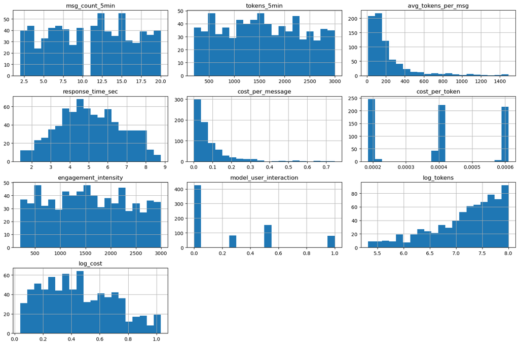

```python
numeric_cols = [
    'msg_count_5min', 'tokens_5min', 'avg_tokens_per_msg',
    'response_time_sec', 'cost_per_message', 'cost_per_token',
    'engagement_intensity', 'model_user_interaction', 'log_tokens', 'log_cost'
]

df[numeric_cols].hist(bins=20, figsize=(15,10))
plt.tight_layout()
plt.show()
```

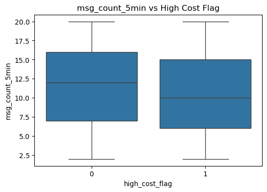

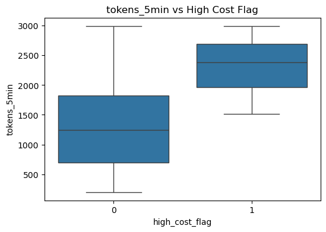

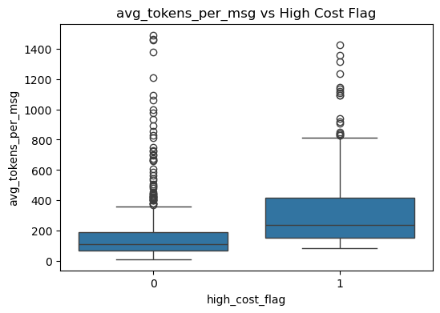

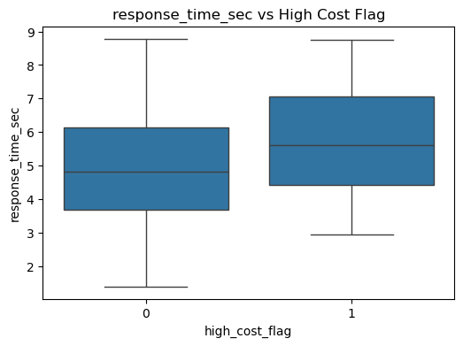

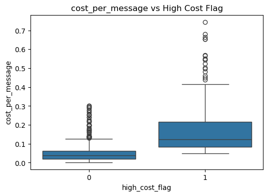

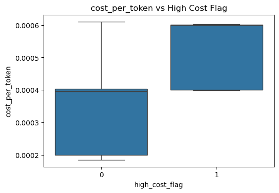

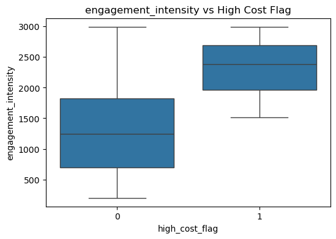

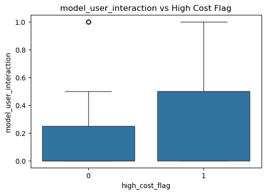

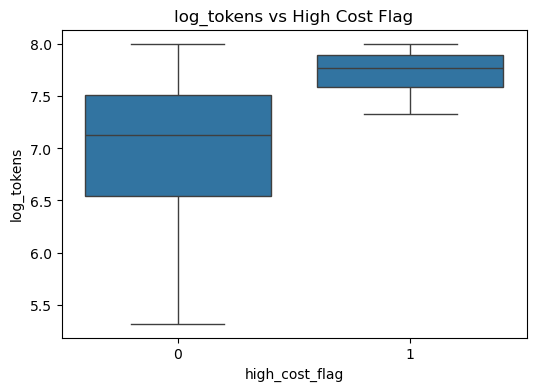

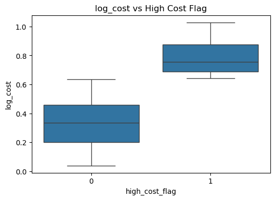

```python
for col in numeric_cols:
    plt.figure(figsize=(6,4))
    sns.boxplot(x='high_cost_flag', y=col, data=df)
    plt.title(f'{col} vs High Cost Flag')
    plt.show()
```

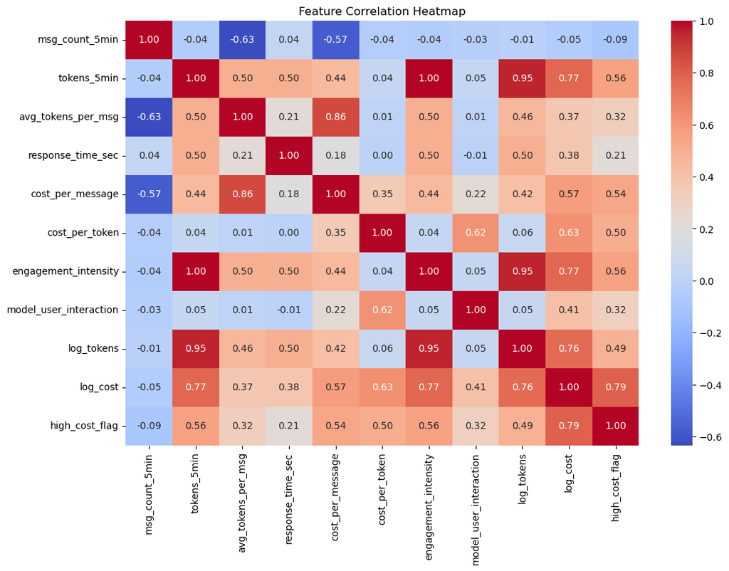

```python
plt.figure(figsize=(12,8))
corr_cols = numeric_cols + ['high_cost_flag']
sns.heatmap(df[corr_cols].corr(), annot=True, fmt=".2f", cmap='coolwarm')
plt.title("Feature Correlation Heatmap")
plt.show()
```

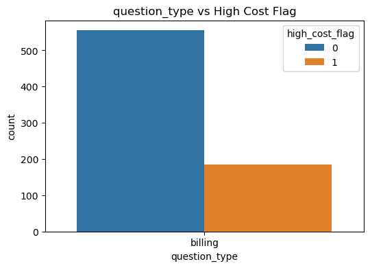

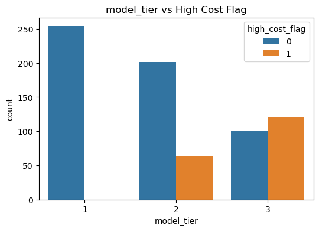

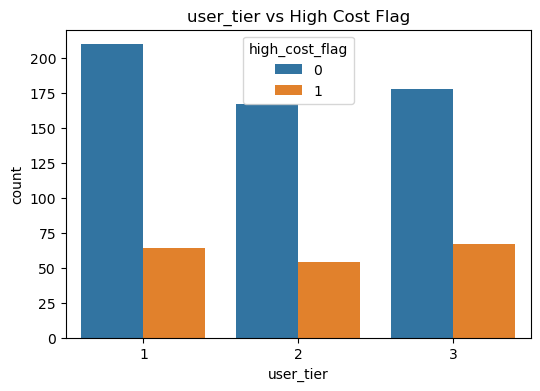

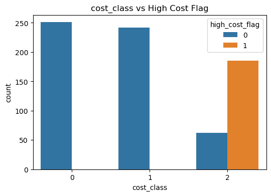

```python
cat_cols = ['question_type', 'model_tier', 'user_tier', 'cost_class']

for col in cat_cols:
    plt.figure(figsize=(6,4))
    sns.countplot(x=col, hue='high_cost_flag', data=df)
    plt.title(f'{col} vs High Cost Flag')
    plt.show()
```

```python
prob_success = (
    0.4
    + 0.05 * df['msg_count_5min_norm']
    - 0.05 * df['response_time_sec']
    + 0.05 * df['avg_tokens_per_msg_norm']
    + 0.05 * df['model_tier_norm']
)

prob_success = np.clip(prob_success, 0.1, 0.9)

df['conversation_success'] = np.random.binomial(1, prob_success)
```

```python
df.columns
```

```
Index(['convo_id', 'msg_count_5min', 'tokens_5min', 'avg_tokens_per_msg',
       'model_tier', 'user_tier', 'total_cost_usd', 'msg_count_5min_norm',
       'tokens_5min_norm', 'avg_tokens_per_msg_norm', 'model_tier_norm',
       'user_tier_norm', 'response_time_sec', 'cost_per_message',
       'cost_per_token', 'engagement_intensity', 'model_user_interaction',
       'log_tokens', 'log_cost', 'question_type', 'high_cost_flag',
       'cost_class', 'cost_per_message_norm', 'cost_per_token_norm',
       'engagement_intensity_norm', 'model_user_interaction_norm',
       'log_tokens_norm', 'log_cost_norm', 'conversation_success'],
      dtype='object')
```

```python
numeric_features = [
    'msg_count_5min_norm', 'tokens_5min_norm', 'avg_tokens_per_msg_norm',
    'response_time_sec', 'cost_per_message_norm', 'cost_per_token_norm',
    'engagement_intensity_norm', 'model_user_interaction_norm',
    'log_tokens_norm', 'log_cost_norm'
]

categorical_features = ['question_type']

y = df['conversation_success']

preprocessor = ColumnTransformer(
    transformers=[
        ('cat', OneHotEncoder(), categorical_features)
    ],
    remainder='passthrough'
)

X = preprocessor.fit_transform(df[categorical_features + numeric_features])
```

```python
X_train, X_test, y_train, y_test = train_test_split(
    X, y, test_size=0.2, random_state=42, stratify=y
)
```

**1. KNN**

```
KNN Accuracy: 0.75
              precision    recall  f1-score   support

           0       0.80      0.91      0.85       117
           1       0.29      0.13      0.18        31

    accuracy                           0.75       148
   macro avg       0.54      0.52      0.52       148
weighted avg       0.69      0.75      0.71       148
```

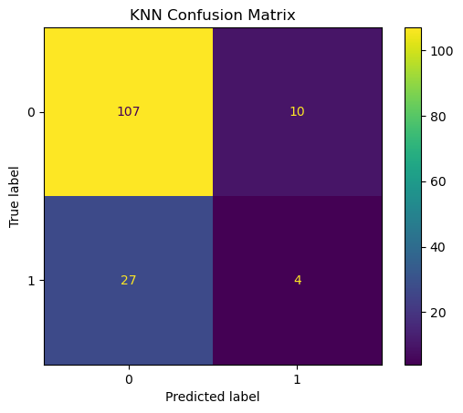

```python
knn = KNeighborsClassifier(n_neighbors=5)
knn.fit(X_train, y_train)

y_pred_knn = knn.predict(X_test)
print("KNN Accuracy:", accuracy_score(y_test, y_pred_knn))
print(classification_report(y_test, y_pred_knn))

ConfusionMatrixDisplay.from_estimator(knn, X_test, y_test)
plt.title("KNN Confusion Matrix")
plt.show()
```

**2. LOGISTIC REGRESSION**

```
Logistic Regression Accuracy: 0.7905405405405406
              precision    recall  f1-score   support

           0       0.79      1.00      0.88       117
           1       0.00      0.00      0.00        31

    accuracy                           0.79       148
   macro avg       0.40      0.50      0.44       148
weighted avg       0.62      0.79      0.70       148
```

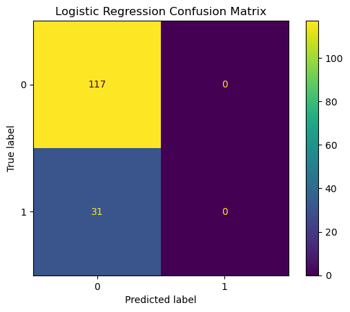

```python
logreg = LogisticRegression(max_iter=1000)
logreg.fit(X_train, y_train)

y_pred_lr = logreg.predict(X_test)
print("Logistic Regression Accuracy:", accuracy_score(y_test, y_pred_lr))
print(classification_report(y_test, y_pred_lr))

ConfusionMatrixDisplay.from_estimator(logreg, X_test, y_test)
plt.title("Logistic Regression Confusion Matrix")
plt.show()
```

**3. LDA**

```
LDA Accuracy: 0.777027027027027
              precision    recall  f1-score   support

           0       0.79      0.98      0.87       117
           1       0.00      0.00      0.00        31

    accuracy                           0.78       148
   macro avg       0.39      0.49      0.44       148
weighted avg       0.62      0.78      0.69       148
```

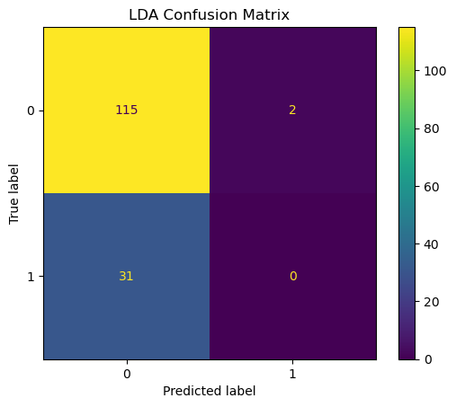

```python
lda = LDA()
lda.fit(X_train, y_train)

y_pred_lda = lda.predict(X_test)
print("LDA Accuracy:", accuracy_score(y_test, y_pred_lda))
print(classification_report(y_test, y_pred_lda))

ConfusionMatrixDisplay.from_estimator(lda, X_test, y_test)
plt.title("LDA Confusion Matrix")
plt.show()
```

**4. QDA**

```
QDA Accuracy: 0.7905405405405406
              precision    recall  f1-score   support

           0       0.79      1.00      0.88       117
           1       0.00      0.00      0.00        31

    accuracy                           0.79       148
   macro avg       0.40      0.50      0.44       148
weighted avg       0.62      0.79      0.70       148
```

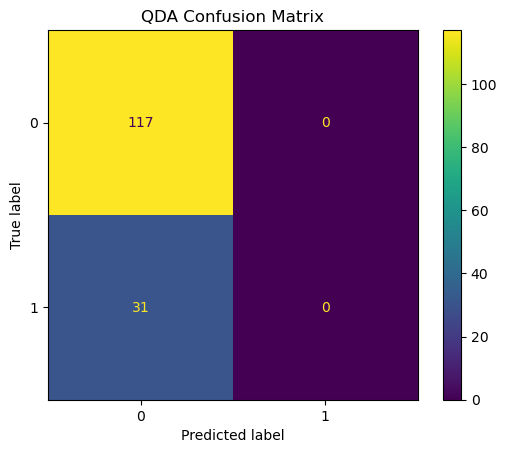

```python
qda = QDA()
qda.fit(X_train, y_train)

y_pred_qda = qda.predict(X_test)
print("QDA Accuracy:", accuracy_score(y_test, y_pred_qda))
print(classification_report(y_test, y_pred_qda))
ConfusionMatrixDisplay.from_estimator(qda, X_test, y_test)
plt.title("QDA Confusion Matrix")
plt.show()
```

**CONCLUSION**

class 1 recall and precision indicates that this is a class imbalance case

we can try this using Random Forest or can use text embeddings for feature engneering